# Groep 5: type passanten

## Eerste aanzet tot clusteranalyse

Door features per devices uit de data te halen, kan met behulp van een clusteranalyse een indeling gemaakt worden in type passant. Hierbij kan bijvoorbeeld gedacht worden aan bewoners die op doordeweekse ochtenden een hogere activiteit laten zien en bezoekers die mogelijk meer meetpunten passeren dan bewoners (die vooral hoog scoren op één meetpunt).

Het blijkt dat veel devices voornamelijk gemeten worden door één punt:

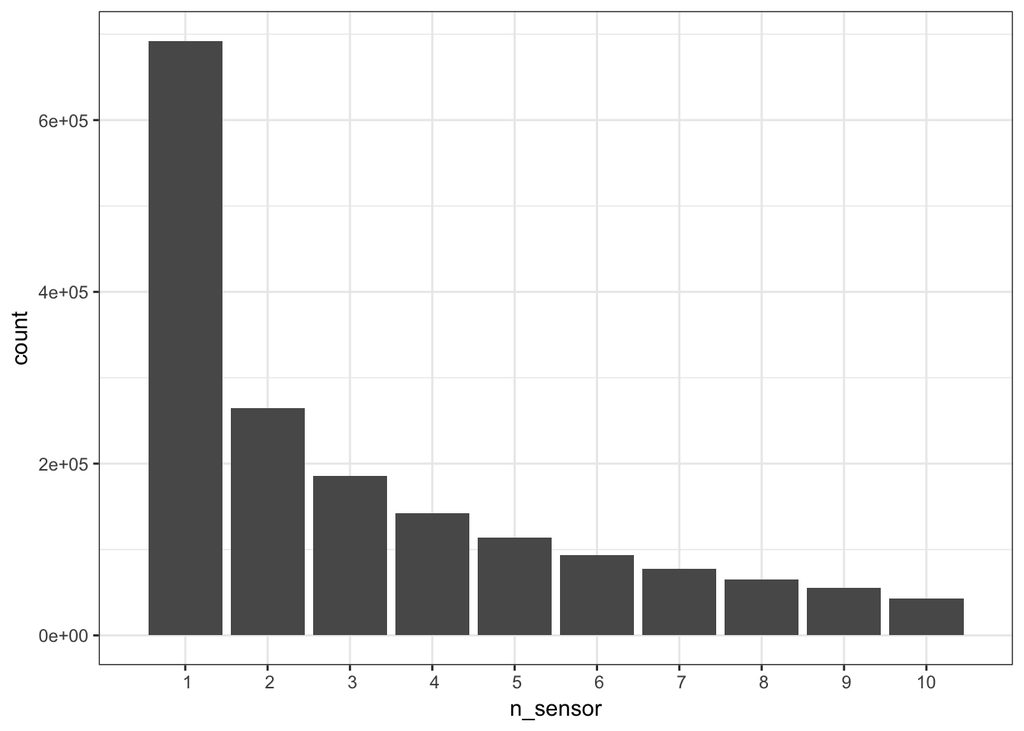

```r
# meetpuntverdeling devices in de zin van spreiding.
n_per_device <- loc %>%
  distinct(code_address, VirtualSensorCode) %>%
  count(code_address, VirtualSensorCode) %>%
  group_by(code_address) %>%
  summarise(n_sensor = sum(n))

# verdeling aantallen meetpunten voor devices
n_per_device %>%
  ggplot(aes(n_sensor)) +
  geom_bar() +
  scale_x_discrete(limits = 1:10)
```

Het berekenen van score op de ochtendspits:

```r
# score op ochtendspits
spits <- loc %>%
  filter(uur == 7 | uur == 8) %>%
  count(code_address) %>%
  arrange(desc(n))
```

Nagaan of men ook in de regen blijft rondlopen. Waarbij regen een aanname is omdat het niet zeker is of het ook in de binnenstad heeft geregend op dat moment.

```r
# door weer en wind aanwezig?
regen_uur <- knmi %>%
  mutate(uur_dttm = floor_date(tijd, 'hour'),
         uur = hour(tijd)) %>%
  filter(uur > 8, uur < 17) %>%
  select(uur_dttm, neerslag)

regen_uur_score <- loc %>%
  mutate(uur_dttm = floor_date(DateTimeLocal, 'hour')) %>%
  count(uur_dttm, code_address)
  left_join(regen_uur)
```

# Clusteren op 2 groepen

```r
# create set for clustering
device_clustering <- loc %>%
  distinct(code_address) %>%
  left_join(n_per_device) %>%
  left_join(spits) %>%
  rename(spits_score = n) %>%
  mutate(spits_score = ifelse(is.na(spits_score), 0, spits_score))
```

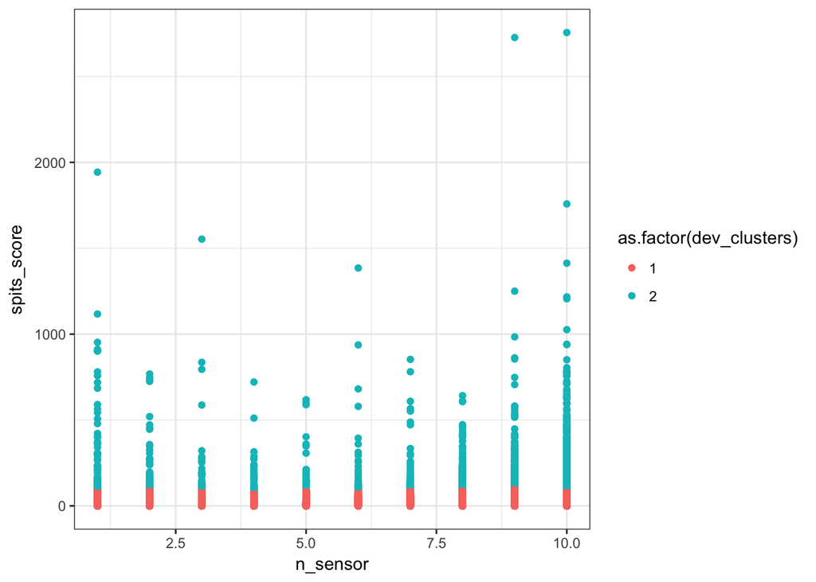

```r
dev_clusters <- device_clustering %>%
  select(n_sensor, spits_score) %>%
  kmeans(., 2) %>%
  .$cluster

res_cluster <- cbind(device_clustering, dev_clusters) %>% as_tibble()

res_cluster %>%
  ggplot(aes(n_sensor, spits_score, color = as.factor(dev_clusters))) +
  geom_point()
```

Resultaten bekijken door random routineplots te genereren uit één van de groepen.

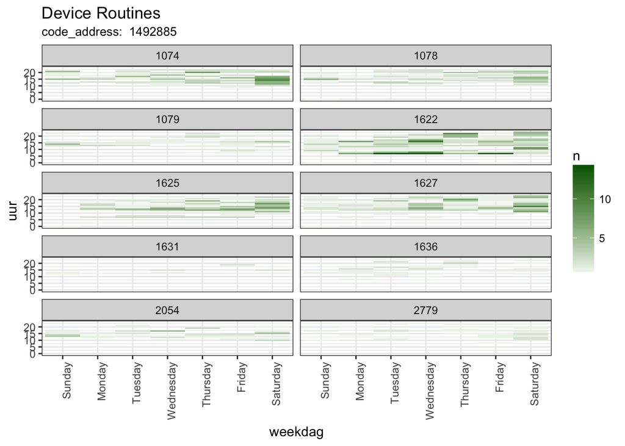

```r
# random testen: cluster 2 heeft meer routines. Lijkt erop dat 1 incidenteler spul is
view_routines(sample(res_cluster[res_cluster$dev_clusters == 2,]$code_address, 1))
```

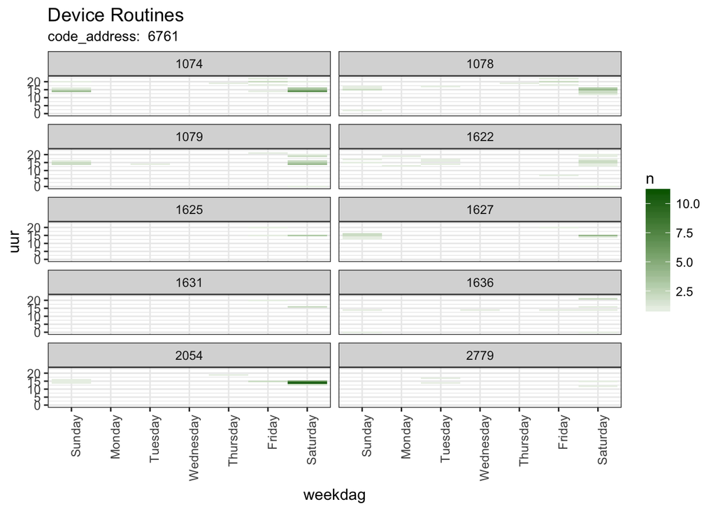

```r
view_routines(sample(res_cluster[res_cluster$dev_clusters == 1,]$code_address, 1))
```

Voortschrijdend inzicht obv bovenstaande bevindingen leert dat er mogelijk 3 groepen zijn: residentieel (bewoners/werkenden), vaste bezoekers en incidentele bezoekers. Dus clusteren op 3 groepen zou dit onderscheid moeten kunnen geven.

```r
dev_clusters3 <- device_clustering %>%
  select(n_sensor, spits_score) %>%
  kmeans(., 3) %>%
  .$cluster

res_clusters3 <- cbind(device_clustering, dev_clusters3) %>% as_tibble()

kable(table(res_clusters3$dev_clusters3))
```

[output not shown]

Cluster 1

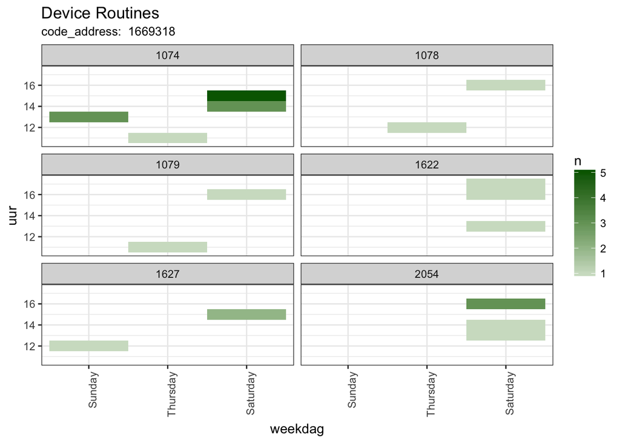

```r
view_routines(sample(res_clusters3[res_clusters3$dev_clusters3 == 1,]$code_address, 1))
```

Cluster 2

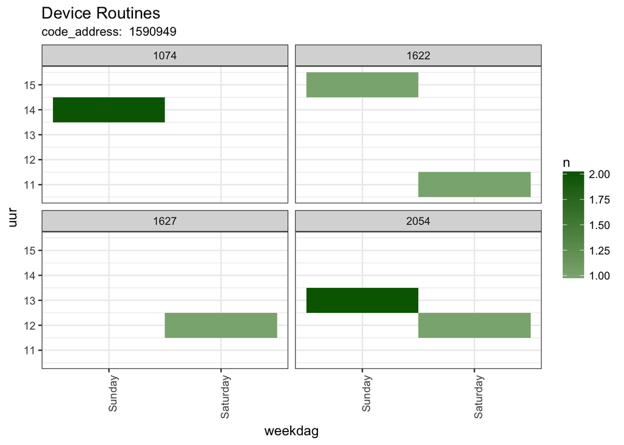

```r
view_routines(sample(res_clusters3[res_clusters3$dev_clusters3 == 2,]$code_address, 1))
```

Cluster 3

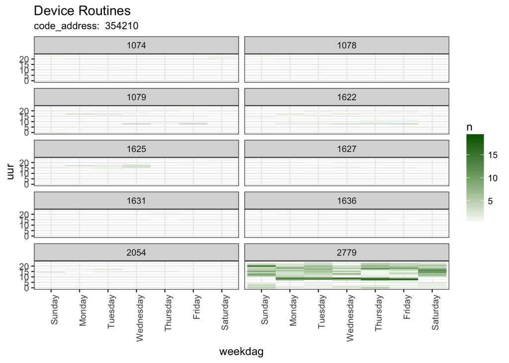

```r
view_routines(sample(res_clusters3[res_clusters3$dev_clusters3 == 3,]$code_address, 1))
```

## Conclusie

Het zou een manier kunnen zijn om onderscheid te maken tussen 3 groepen passanten. Het weer zit er nu nog niet in (bedankt `lubridate`). Meer features zouden deze manier robuuster kunnen maken.